# Análisis Estadístico Descriptivo e Inferencial del Impacto de Condiciones Climáticas y Prácticas Agrícolas sobre el Calibre de las Paltas Hass

### 4.2.3. Visualización de variables categóricas

#### 4.2.3.1. Tabla de frecuencia y Barplot para las variables categóricas más relevantes del dataset ‘calibre’

##### 4.2.3.1.1. Variable calibre

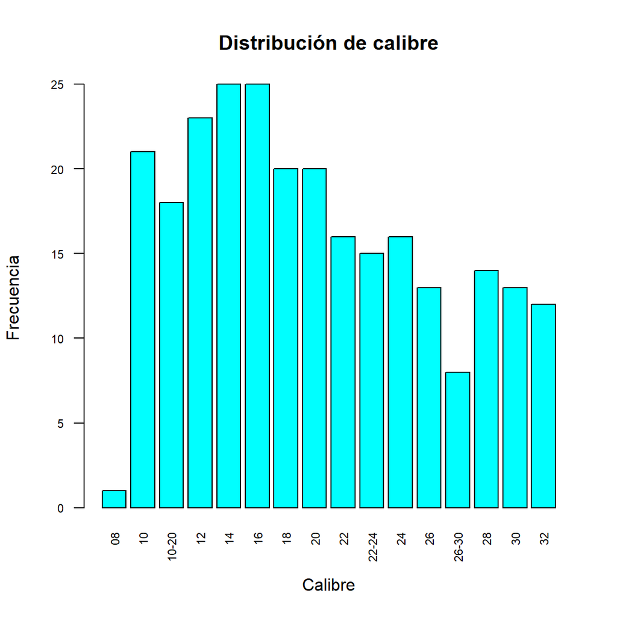

```r
# Tabla de frecuencia para la variable categórica calibre
calibres_categoria_freq <- table(calibres$calibre)

# Barplot para la variable categórica calibre
par(cex.axis=0.7)
barplot(calibres_categoria_freq, main="Distribución de calibre", col="cyan", las=2, xlab="Calibre", ylab="Frecuencia")
```

#### 4.2.3.2. Tabla de frecuencia y Barplot para las variables categóricas más relevantes del dataset Reporte

##### 4.2.3.2.1. Variable fundo

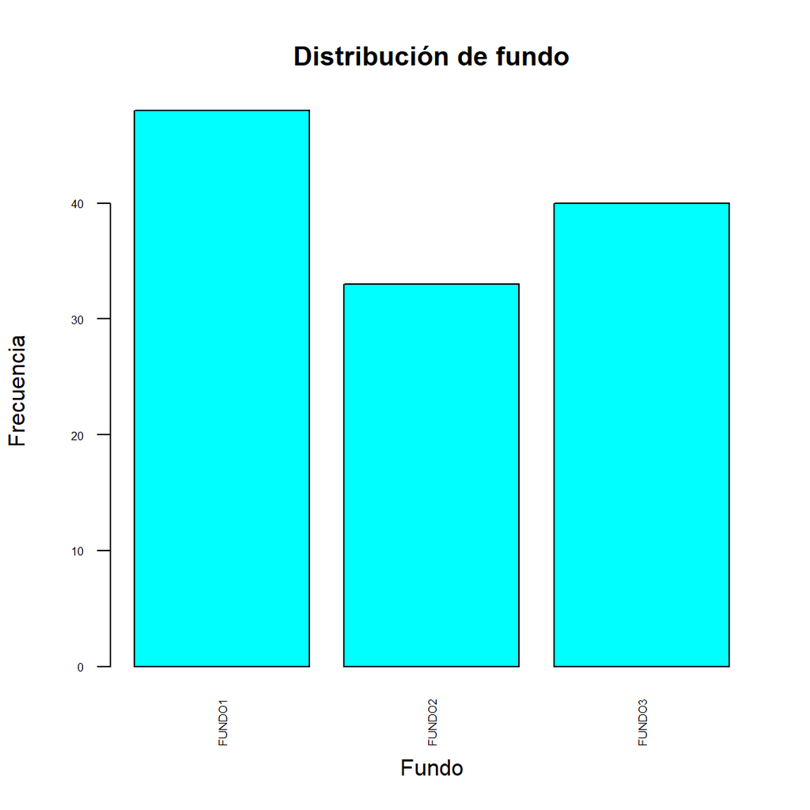

```r
# Tabla de frecuencia para la variable categórica fundo
reporte_categoria_freq <- table(reporte$fundo)

# Barplot para la variable categórica fundo
par(cex.axis=0.5)
barplot(reporte_categoria_freq, main="Distribución de fundo", col="cyan", las=2, xlab="Fundo", ylab="Frecuencia")
```

**Interpretación**: Hay tres categorías de fundo representadas: FUNDO1, FUNDO2 y FUNDO3. FUNDO1 tiene la mayor frecuencia, indicando que hay más registros o datos asociados a esta categoría en el conjunto de datos.FUNDO2 tiene una frecuencia significativamente menor en comparación con FUNDO1, lo que indica menos registros asociados a esta categoría. FUNDO3 tiene una frecuencia similar a FUNDO1, lo cual sugiere una cantidad de registros comparable con la primera categoría.

##### 4.2.3.2.2. Variable lote

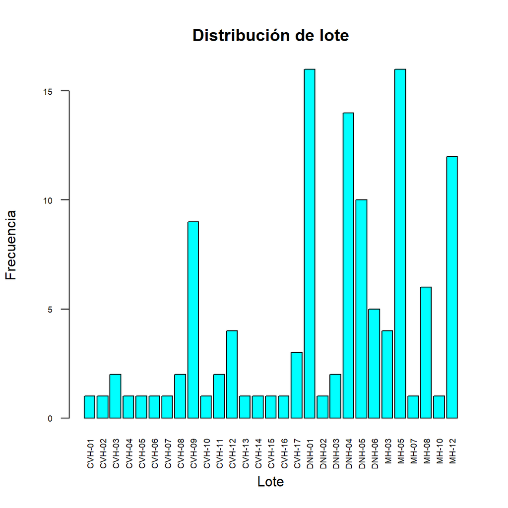

```r
# Tabla de frecuencia para la variable categórica lote
reporte_categoria_freq <- table(reporte$lote)

# Barplot para la variable categórica lote
par(cex.axis=0.6)
barplot(reporte_categoria_freq, main="Distribución de lote", col="cyan", las=2, xlab="Lote", ylab="Frecuencia")
```

**Interpretación**: La variable lote presenta una variedad de categorías, que parecen estar codificadas con combinaciones de letras y números (como CVH-01, DNH-03, MH-10, etc.). Las frecuencias de las diferentes categorías de lote varían significativamente, con algunas categorías mostrando una frecuencia mucho mayor que otras. Esto sugiere que algunos lotes tienen más registros asociados que otros. No se observa un patrón uniforme en las frecuencias, indicando que la distribución de registros por lote no es homogénea.

##### 4.2.3.2.3. Variable insumo_para_tratamiento

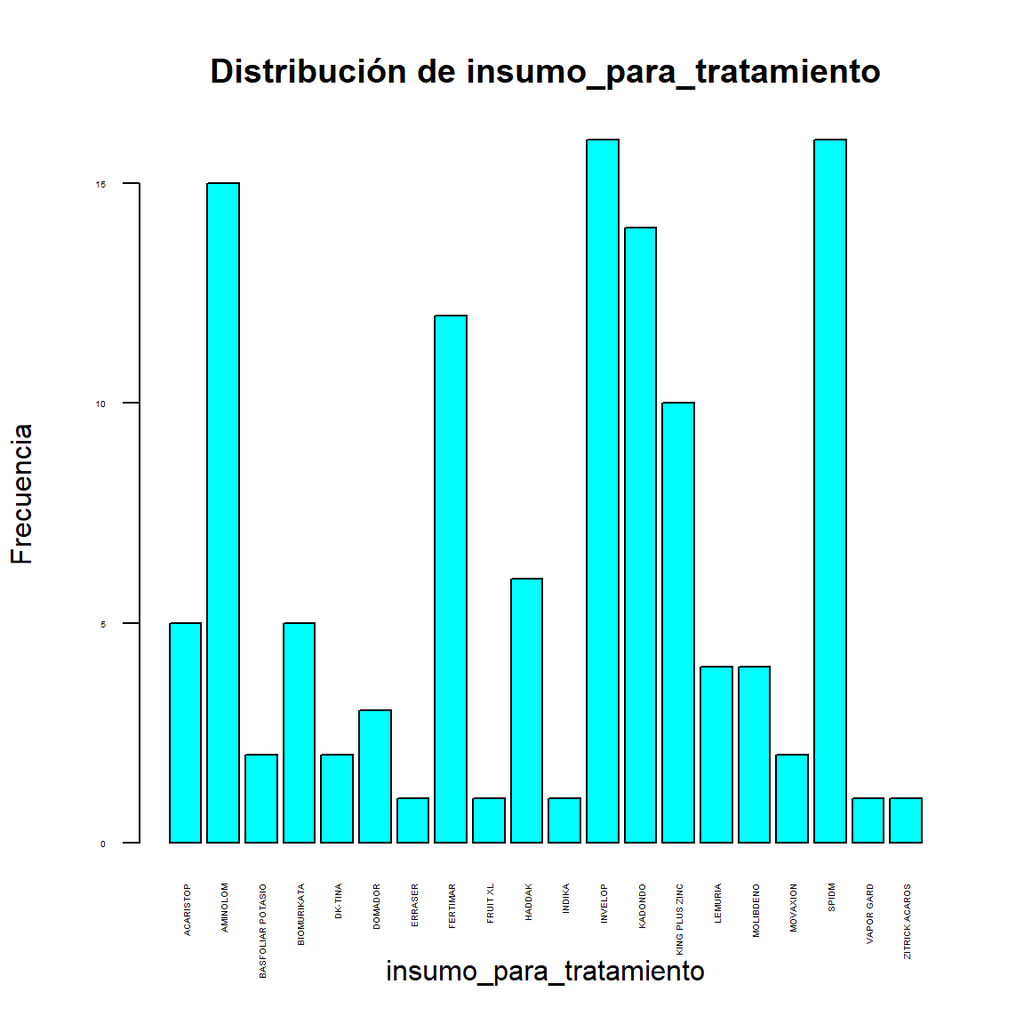

```r
# Tabla de frecuencia para la variable categórica insumo_para_tratamiento
reporte_categoria_freq <- table(reporte$insumo_para_tratamiento)

# Barplot para la variable categórica insumo_para_tratamiento
par(cex.axis=0.3)
barplot(reporte_categoria_freq, main="Distribución de insumo_para_tratamiento", col="cyan", las=2, xlab="insumo_para_tratamiento", ylab="Frecuencia")
```

**Interpretación**: Las categorías de insumos tienen frecuencias variadas, lo que indica que algunos insumos se utilizan más comúnmente que otros. Algunos insumos, como los representados por las barras más altas, destacan por su uso frecuente, lo que podría indicar una preferencia o mayor necesidad de estos dentro del contexto de los tratamientos. Por el contrario, los insumos representados por barras más cortas se usan menos, lo que podría deberse a que son menos conocidos, más caros, o quizás solo son necesarios para aplicaciones específicas.